# Project: Identify Customer Segments

### Step 2.2: Perform Dimensionality Reduction

On your scaled data, you are now ready to apply dimensionality reduction techniques.

- Use sklearn's [PCA](http://scikit-learn.org/stable/modules/generated/sklearn.decomposition.PCA.html) class to apply principal component analysis on the data, thus finding the vectors of maximal variance in the data. To start, you should not set any parameters (so all components are computed) or set a number of components that is at least half the number of features (so there's enough features to see the general trend in variability).
- Check out the ratio of variance explained by each principal component as well as the cumulative variance explained. Try plotting the cumulative or sequential values using matplotlib's [`plot()`](https://matplotlib.org/api/_as_gen/matplotlib.pyplot.plot.html) function. Based on what you find, select a value for the number of transformed features you'll retain for the clustering part of the project.
- Once you've made a choice for the number of components to keep, make sure you re-fit a PCA instance to perform the decided-on transformation.

```python
# Apply PCA to the data.

from sklearn.decomposition import PCA
pca = PCA()
azdias_pca = pca.fit_transform(azdias_scaled)
```

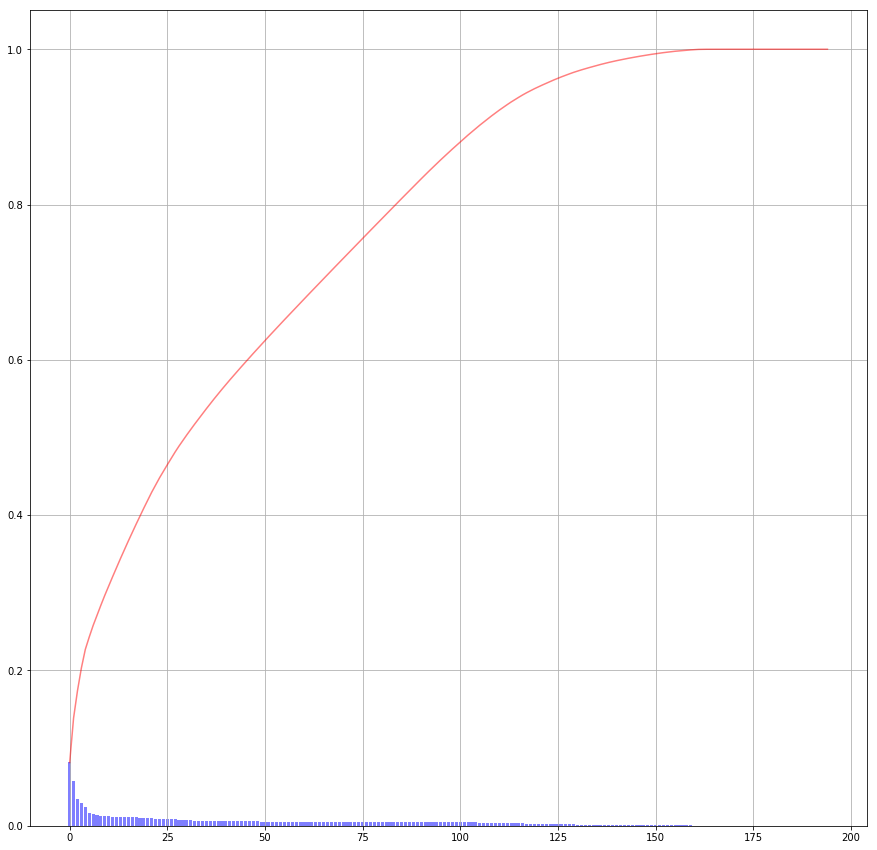

```python
# Investigate the variance accounted for by each principal component.
length_of_vals = range(len(pca.explained_variance_ratio_))
e_var_ratio = pca.explained_variance_ratio_
cum_e_var_ratio = np.cumsum(e_var_ratio)

plt.figure(figsize=(15, 15))
plt.bar(length_of_vals, e_var_ratio, color='b', alpha=0.5)
plt.plot(length_of_vals, cum_e_var_ratio, color='r', alpha=0.5)
plt.grid()
plt.show()
```

```python
num_comps = e_var_ratio[e_var_ratio*100 >= 1]
# display the components that are responsible for at least 1% of the variance
display(num_comps)
# total variance represented by these components
display(num_comps.sum())
# how many components are there
display(len(num_comps))
```

```
array([ 0.08152354,  0.05740819,  0.03508123,  0.02933187,  0.02376263,
        0.01588765,  0.01486952,  0.01330588,  0.01305797,  0.01268224,
        0.01202211,  0.01190335,  0.01175272,  0.01153546,  0.01127673,
        0.01120358,  0.01096597,  0.01070865,  0.01061635,  0.01040771,
        0.01028315])
```

```
0.41958649886607091
```

```
21
```

```python
# determine how many components you need to retain 60% of the variance
num_comps = len(cum_e_var_ratio[cum_e_var_ratio <= 0.6])
display(num_comps)
```

```
46
```

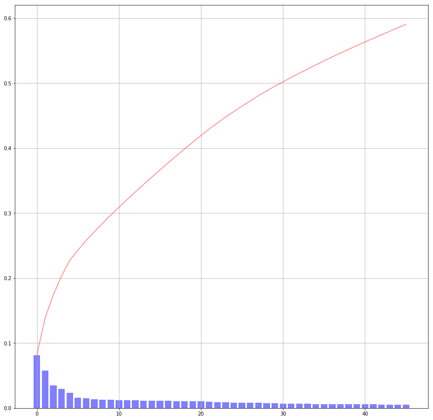

```python
# Re-apply PCA to the data while selecting for number of components to retain.
pca = PCA(num_comps)
azdias_pca = pca.fit_transform(azdias_scaled)
length_of_vals = range(len(pca.explained_variance_ratio_))
e_var_ratio = pca.explained_variance_ratio_
cum_e_var_ratio = np.cumsum(e_var_ratio)

plt.figure(figsize=(15, 15))
plt.bar(length_of_vals, e_var_ratio, color='b', alpha=0.5)
plt.plot(length_of_vals, cum_e_var_ratio, color='r', alpha=0.5)
plt.grid()
plt.show()
```

### Discussion 2.2: Perform Dimensionality Reduction

(Double-click this cell and replace this text with your own text, reporting your findings and decisions regarding dimensionality reduction. How many principal components / transformed features are you retaining for the next step of the analysis?)

For dimension reduction, I used principal component analysis as required. I wanted to retain only the components that resulted in the highest variance. In my first pass, I considered the Kaiser rule [1] states that all eigen values of maginitude less than 1 should be dropped but in my case all them have a magnitude of less than 1 as shown by the scree plot of the explained_variance ratio. Therefore, I chose to set my cutoff at 1%. However using this rule I only got 42% of the total variance.Thus,

I then changed to take all components that resulted in 60% of the total variance (recommended by my course reviewer) and I ended up with 46 principal components.

I earlier tried to maintain 90% variance but the performance was so bad... I could not determine the number of clusters in the next section.

[1] https://www.geo.fu-berlin.de/en/v/soga/Geodata-analysis/Principal-Component-Analysis/principal-components-basics/Choose-principal-components/index.html

### Step 2.3: Interpret Principal Components

Now that we have our transformed principal components, it's a nice idea to check out the weight of each variable on the first few components to see if they can be interpreted in some fashion.

As a reminder, each principal component is a unit vector that points in the direction of highest variance (after accounting for the variance captured by earlier principal components). The further a weight is from zero, the more the principal component is in the direction of the corresponding feature. If two features have large weights of the same sign (both positive or both negative), then increases in one tend expect to be associated with increases in the other. To contrast, features with different signs can be expected to show a negative correlation: increases in one variable should result in a decrease in the other.

- To investigate the features, you should map each weight to their corresponding feature name, then sort the features according to weight. The most interesting features for each principal component, then, will be those at the beginning and end of the sorted list. Use the data dictionary document to help you understand these most prominent features, their relationships, and what a positive or negative value on the principal component might indicate.
- You should investigate and interpret feature associations from the first three principal components in this substep. To help facilitate this, you should write a function that you can call at any time to print the sorted list of feature weights, for the *i*-th principal component. This might come in handy in the next step of the project, when you interpret the tendencies of the discovered clusters.

```python
# Map weights for the first principal component to corresponding feature names
# and then print the linked values, sorted by weight.
# HINT: Try defining a function here or in a new cell that you can reuse in the
# other cells.

def sort_weights(k):

    inds = pca.components_[(k-1)].argsort()[::-1] # reverse the order to make list descending
    sorted_pca_weights = pd.DataFrame(pca.components_[(k-1)][inds])
    sorted_pca_weights.index = azdias_new.columns[inds]
    sorted_pca_weights.columns=['PCA Weights']

    return sorted_pca_weights

# the first five elements
display(sort_weights(1))
```

|  | PCA Weights |
| --- | --- |
| LP_STATUS_GROB_1.0 | 0.191947 |
| HH_EINKOMMEN_SCORE | 0.184450 |
| ECON_STATUS | 0.181356 |
| PLZ8_ANTG3 | 0.177048 |
| PLZ8_ANTG4 | 0.171069 |
| ORTSGR_KLS9 | 0.149242 |
| FINANZ_HAUSBAUER | 0.148293 |
| EWDICHTE | 0.148089 |
| LP_STATUS_FEIN_1.0 | 0.126391 |
| KBA05_ANTG4 | 0.126228 |
| PLZ8_ANTG2 | 0.121839 |
| KBA05_ANTG3 | 0.115237 |
| ANZ_HAUSHALTE_AKTIV | 0.113131 |
| LP_STATUS_FEIN_2.0 | 0.110595 |
| CAMEO_DEUG_2015_9 | 0.110458 |
| ARBEIT | 0.110152 |
| FINANZ_SPARER | 0.108098 |
| FINANZTYP_1 | 0.108056 |
| RELAT_AB | 0.103846 |
| LP_FAMILIE_FEIN_1.0 | 0.102231 |
| LP_FAMILIE_GROB_1.0 | 0.102231 |
| CAMEO_DEUG_2015_8 | 0.090140 |
| SEMIO_PFLICHT | 0.077333 |
| ZABEOTYP_5 | 0.074750 |
| SEMIO_REL | 0.073100 |
| YEARS | 0.065707 |
| GEBAEUDETYP_3.0 | 0.065407 |
| SEMIO_RAT | 0.064123 |
| CAMEO_DEU_2015_8A | 0.061742 |
| GFK_URLAUBERTYP_12.0 | 0.061173 |
| ... | ... |
| NATIONALITAET_KZ_1.0 | -0.062606 |
| CAMEO_DEUG_2015_3 | -0.063927 |
| CAMEO_DEUG_2015_4 | -0.071065 |
| FINANZTYP_2 | -0.074013 |
| ALTERSKATEGORIE_GROB | -0.077632 |
| FINANZ_VORSORGER | -0.078278 |
| LP_FAMILIE_GROB_5.0 | -0.081940 |
| GEBAEUDETYP_1.0 | -0.086688 |
| CAMEO_DEUG_2015_2 | -0.087454 |
| BALLRAUM | -0.092525 |
| GEBAEUDETYP_RASTER | -0.094408 |
| ANZ_PERSONEN | -0.097359 |
| ZABEOTYP_1 | -0.097584 |
| MOVEMENT | -0.106043 |
| GREEN_AVANTGARDE | -0.106043 |
| LP_STATUS_FEIN_9.0 | -0.107536 |
| FAM_STAGE | -0.107557 |
| LP_STATUS_GROB_4.0 | -0.108783 |
| LP_STATUS_GROB_5.0 | -0.115860 |
| LP_STATUS_FEIN_10.0 | -0.115860 |
| INNENSTADT | -0.122790 |
| PLZ8_GBZ | -0.129482 |
| KONSUMNAEHE | -0.132621 |
| LP_LEBENSPHASE_GROB | -0.134316 |
| LP_LEBENSPHASE_FEIN | -0.147384 |
| KBA05_GBZ | -0.177389 |
| PLZ8_ANTG1 | -0.177892 |
| FINANZ_MINIMALIST | -0.185870 |
| KBA05_ANTG1 | -0.186143 |
| MOBI_REGIO | -0.201062 |

195 rows × 1 columns

```python
# Map weights for the second principal component to corresponding feature names
# and then print the linked values, sorted by weight.

# the first five elements
display(sort_weights(2))
```

|  | PCA Weights |
| --- | --- |
| ALTERSKATEGORIE_GROB | 0.235092 |
| FINANZ_VORSORGER | 0.220240 |
| ZABEOTYP_3 | 0.199772 |
| SEMIO_ERL | 0.181231 |
| SEMIO_LUST | 0.163861 |
| RETOURTYP_BK_S | 0.156240 |
| W_KEIT_KIND_HH | 0.130162 |
| CJT_GESAMTTYP_2.0 | 0.109875 |
| FINANZTYP_5 | 0.096195 |
| FINANZ_MINIMALIST | 0.094374 |
| FINANZTYP_2 | 0.093342 |
| LP_STATUS_FEIN_1.0 | 0.091137 |
| FINANZ_HAUSBAUER | 0.079794 |
| SHOPPER_TYP_3.0 | 0.075334 |
| SEMIO_KRIT | 0.074702 |
| CJT_GESAMTTYP_1.0 | 0.071369 |
| NATIONALITAET_KZ_1.0 | 0.068409 |
| FINANZTYP_6 | 0.067378 |
| LP_FAMILIE_GROB_1.0 | 0.065123 |
| LP_FAMILIE_FEIN_1.0 | 0.065123 |
| GFK_URLAUBERTYP_4.0 | 0.058185 |
| PLZ8_ANTG3 | 0.057240 |
| EWDICHTE | 0.055972 |
| SEMIO_KAEM | 0.054802 |
| ORTSGR_KLS9 | 0.054578 |
| PLZ8_ANTG4 | 0.053613 |
| WOHNDAUER_2008 | 0.053444 |
| LP_STATUS_FEIN_3.0 | 0.049801 |
| ECON_STATUS | 0.049750 |
| KBA05_ANTG4 | 0.045875 |
| ... | ... |
| LP_FAMILIE_GROB_5.0 | -0.051353 |
| KBA05_GBZ | -0.054087 |
| MOBI_REGIO | -0.054686 |
| LP_LEBENSPHASE_GROB | -0.054867 |
| CJT_GESAMTTYP_4.0 | -0.054903 |
| ZABEOTYP_1 | -0.056038 |
| PLZ8_ANTG1 | -0.056073 |
| SEMIO_SOZ | -0.063229 |
| LP_FAMILIE_GROB_4.0 | -0.069515 |
| ANZ_PERSONEN | -0.070296 |
| FINANZTYP_3 | -0.072197 |
| GFK_URLAUBERTYP_9.0 | -0.074381 |
| LP_STATUS_FEIN_5.0 | -0.080097 |
| FINANZTYP_4 | -0.088468 |
| ZABEOTYP_5 | -0.091871 |
| LP_STATUS_FEIN_2.0 | -0.098406 |
| ZABEOTYP_4 | -0.108664 |
| SEMIO_MAT | -0.131396 |
| SEMIO_FAM | -0.134408 |
| FINANZTYP_1 | -0.135522 |
| ONLINE_AFFINITAET | -0.162538 |
| SEMIO_KULT | -0.166433 |
| SEMIO_RAT | -0.170688 |
| FINANZ_ANLEGER | -0.204277 |
| SEMIO_PFLICHT | -0.208575 |
| SEMIO_TRADV | -0.209196 |
| FINANZ_UNAUFFAELLIGER | -0.214774 |
| SEMIO_REL | -0.216589 |
| FINANZ_SPARER | -0.229304 |
| YEARS | -0.239558 |

195 rows × 1 columns

```python
# Map weights for the third principal component to corresponding feature names
# and then print the linked values, sorted by weight.
# the first five elements
display(sort_weights(3))
```

|  | PCA Weights |
| --- | --- |
| SEMIO_VERT | 0.318478 |
| SEMIO_FAM | 0.259053 |
| SEMIO_SOZ | 0.257334 |
| SEMIO_KULT | 0.248967 |
| FINANZTYP_5 | 0.136743 |
| FINANZ_MINIMALIST | 0.128756 |
| SHOPPER_TYP_0.0 | 0.123272 |
| ZABEOTYP_1 | 0.116857 |
| SEMIO_REL | 0.113023 |
| SEMIO_MAT | 0.086573 |
| MOVEMENT | 0.078727 |
| GREEN_AVANTGARDE | 0.078727 |
| RETOURTYP_BK_S | 0.076066 |
| EWDICHTE | 0.067357 |
| ORTSGR_KLS9 | 0.067058 |
| W_KEIT_KIND_HH | 0.065271 |
| LP_STATUS_FEIN_10.0 | 0.055633 |
| LP_STATUS_GROB_5.0 | 0.055633 |
| PLZ8_ANTG4 | 0.051670 |
| PLZ8_ANTG3 | 0.051574 |
| SHOPPER_TYP_1.0 | 0.051146 |
| ZABEOTYP_6 | 0.049905 |
| FINANZ_VORSORGER | 0.046849 |
| LP_STATUS_FEIN_3.0 | 0.045606 |
| LP_STATUS_FEIN_1.0 | 0.045316 |
| PLZ8_ANTG2 | 0.037609 |
| RELAT_AB | 0.036641 |
| ARBEIT | 0.035006 |
| LP_STATUS_GROB_3.0 | 0.033520 |
| GEBAEUDETYP_3.0 | 0.031766 |
| ... | ... |
| GEBAEUDETYP_1.0 | -0.030541 |
| LP_STATUS_GROB_2.0 | -0.031583 |
| PLZ8_GBZ | -0.035756 |
| ZABEOTYP_3 | -0.037578 |
| HH_EINKOMMEN_SCORE | -0.038757 |
| KKK | -0.039928 |
| LP_FAMILIE_FEIN_4.0 | -0.039990 |
| GEBAEUDETYP_RASTER | -0.041949 |
| FINANZ_UNAUFFAELLIGER | -0.045614 |
| YEARS | -0.048647 |
| PLZ8_ANTG1 | -0.048747 |
| KONSUMNAEHE | -0.050613 |
| SHOPPER_TYP_3.0 | -0.050633 |
| BALLRAUM | -0.052976 |
| FINANZ_SPARER | -0.055016 |
| LP_FAMILIE_GROB_3.0 | -0.055503 |
| INNENSTADT | -0.059676 |
| FINANZ_HAUSBAUER | -0.061926 |
| ZABEOTYP_4 | -0.063349 |
| LP_STATUS_FEIN_4.0 | -0.074076 |
| LP_STATUS_FEIN_2.0 | -0.080250 |
| SHOPPER_TYP_2.0 | -0.093713 |
| FINANZTYP_1 | -0.099957 |
| FINANZ_ANLEGER | -0.154056 |
| SEMIO_RAT | -0.154141 |
| SEMIO_ERL | -0.206134 |
| SEMIO_KRIT | -0.264399 |
| SEMIO_DOM | -0.280793 |
| SEMIO_KAEM | -0.313410 |
| ANREDE_KZ | -0.343975 |

195 rows × 1 columns

### Discussion 2.3: Interpret Principal Components

(Double-click this cell and replace this text with your own text, reporting your observations from detailed investigation of the first few principal components generated. Can we interpret positive and negative values from them in a meaningful way?)

**Principal Component 1:** LP_STATUS_GROB_1.0 0.191947 HH_EINKOMMEN_SCORE 0.184450

**Positive** - LP_STATUS_GROB_1.0, HH_EINKOMMEN_SCORE,ECON_STATUS, PLZ8_ANTG3, PLZ8_ANTG4 - LP_STATUS_GROB_1.0 represents low income earners, HH_EINKOMMEN_SCORE represents income level, ECON_STATUS represents the economic status of the individual and PLZ8_ANTG3, PLZ8_ANTG4 represent the number of 6-10 and 10+ family houses in the region. These are expected to be positively correlated because usually, the lower the income, the lower the economic status. Another interesting correlation is that the lower the income status, the more likely to have a bigger family.

**Negative** - KBA05_ANTG1, FINANZ_MINIMALIST, MOBI_REGIO, PLZ8_ANTG1, KBA05_GBZ - KBA05_ANTG1,PLZ8_ANTG1, KBA05_GBZ have to do with the number of 1-2 family buildings and families in the area. Thus it is no suprise that they are correlated. MOBI_REGIO is for movement patterns. I think the correlation here is that smaller families are more likely to move more than bigger families.

Comparing positive and negative principal components shows that low income earners with low economic status move less and vice versa. Low income families have lower financial interest.

Based on the highest magnitudes, this principal component has large positive associations with financial status and income and large negative associations with the neighborhood in terms of number of 1-2 family homes and movement patterns.[2]

**Principal Component 2:**

**Positive** - ALTERSKATEGORIE_GROB, FINANZ_VORSORGER, ZABEOTYP_3 This principal component has positive associations with age, financial preparedeness and the factor considered for power supplier.

**Negative** - FINANZ_ANLEGER, SEMIO_PFLICHT, SEMIO_TRADV, SEMIO_REL, FINANZ_UNAUFFAELLIGER, FINANZ_SPARER, YEARS THis principal component has high negative associations with the years during which a person was a youth, money saving and investment habits and aspects of their personality like how religious, traditional or dutiful they are. In short it combines age, finance and personality aspects.

In summary, this principal component has associations with financial standing or habits, personality and age [2].

**Principal Component 3**

**Positive** - SEMIO_VERT, SEMIO_FAM, SEMIO_KULT SEMIO_SOZ denote dreamful, family-oriented, culture and social-minded. The data seems to suggest that dreamful people are also socially minded.

**Negative**b - SEMIO_DOM, SEMIO_KAEM, SEMIO_ERL, and SEMIO_KRIT denote a critical, dominant and combative attitude. It is not difficult to imagine that dominant person will also most likely have a combative attitude because they are used to being the only one with a say. ANDREDE_KZ denotes the gender.

Comparing the positive with the negative components can show that a person who is socially minded is unlikely to be dominant and combative in nature because they always consider other people in all they do.

This principal component is dominated by personality type. It has both on the negative and positve associations with different aspects of personality type [2] It also has negative associations with the gender.

[2] https://support.minitab.com/en-us/minitab/18/help-and-how-to/modeling-statistics/multivariate/how-to/principal-components/interpret-the-results/key-results/

## Step 3: Clustering

### Step 3.1: Apply Clustering to General Population

You've assessed and cleaned the demographics data, then scaled and transformed them. Now, it's time to see how the data clusters in the principal components space. In this substep, you will apply k-means clustering to the dataset and use the average within-cluster distances from each point to their assigned cluster's centroid to decide on a number of clusters to keep.

- Use sklearn's KMeans class to perform k-means clustering on the PCA-transformed data.
- Then, compute the average difference from each point to its assigned cluster's center. **Hint**: The KMeans object's `.score()` method might be useful here, but note that in sklearn, scores tend to be defined so that larger is better. Try applying it to a small, toy dataset, or use an internet search to help your understanding.
- Perform the above two steps for a number of different cluster counts. You can then see how the average distance decreases with an increasing number of clusters. However, each additional cluster provides a smaller net benefit. Use this fact to select a final number of clusters in which to group the data. **Warning**: because of the large size of the dataset, it can take a long time for the algorithm to resolve. The more clusters to fit, the longer the algorithm will take. You should test for cluster counts through at least 10 clusters to get the full picture, but you shouldn't need to test for a number of clusters above about 30.
- Once you've selected a final number of clusters to use, re-fit a KMeans instance to perform the clustering operation. Make sure that you also obtain the cluster assignments for the general demographics data, since you'll be using them in the final Step 3.3.

```python
# Over a number of different cluster counts...
from sklearn.cluster import KMeans

dist = []

    # run k-means clustering on the data and...
for val in range(2,11):
    kmeans = KMeans(n_clusters=val)
    kmeans_mod = kmeans.fit(azdias_pca)

# compute the average within-cluster distances.
    new_dist = np.abs(kmeans_mod.score(azdias_pca))
    dist.append(new_dist)
```

```python
dist
```

```
[79648591.371105015,
 75228403.060697079,
 72471706.894704387,
 70144149.033325762,
 68669513.369410858,
 67422676.383309335,
 66273751.92570997,
 65215423.097480476,
 64204197.532571398]
```

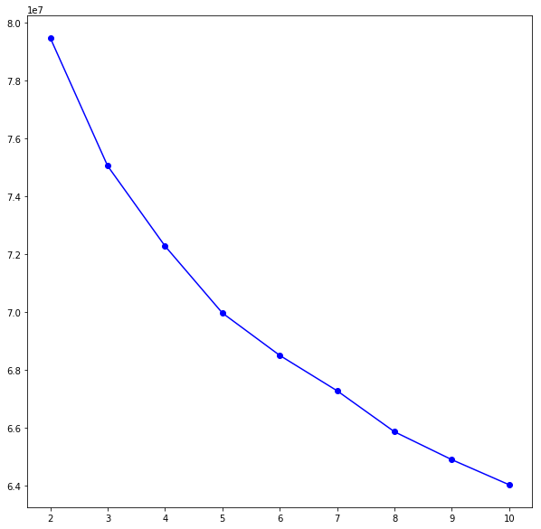

```python
# Investigate the change in within-cluster distance across number of clusters.
# HINT: Use matplotlib's plot function to visualize this relationship.
plt.figure(figsize=(10, 10))
plt.xticks(np.arange(2,11, 1))
plt.plot(range(2,11), dist, marker='o', color='b')
plt.show()
```

```python
# Re-fit the k-means model with the selected number of clusters and obtain cluster predictions for the general population
# I chose 5 clusters using the elbow method (elbow at 5)
from sklearn.cluster import KMeans
kmeans = KMeans(5)
kmeans_mod = kmeans.fit(azdias_pca)
pred = kmeans_mod.predict(azdias_pca)
```

### Discussion 3.1: Apply Clustering to General Population

[1] https://towardsdatascience.com/10-tips-for-choosing-the-optimal-number-of-clusters-277e93d72d92

### Step 3.2: Apply All Steps to the Customer Data

Now that you have clusters and cluster centers for the general population, it's time to see how the customer data maps on to those clusters. Take care to not confuse this for re-fitting all of the models to the customer data. Instead, you're going to use the fits from the general population to clean, transform, and cluster the customer data. In the last step of the project, you will interpret how the general population fits apply to the customer data.

- Don't forget when loading in the customers data, that it is semicolon (`;`) delimited.
- Apply the same feature wrangling, selection, and engineering steps to the customer demographics using the `clean_data()` function you created earlier. (You can assume that the customer demographics data has similar meaning behind missing data patterns as the general demographics data.)
- Use the sklearn objects from the general demographics data, and apply their transformations to the customers data. That is, you should not be using a `.fit()` or `.fit_transform()` method to re-fit the old objects, nor should you be creating new sklearn objects! Carry the data through the feature scaling, PCA, and clustering steps, obtaining cluster assignments for all of the data in the customer demographics data.

```python
# Load in the customer demographics data.
customers = pd.read_csv('Udacity_CUSTOMERS_Subset.csv', sep=';')
customers.head(10)
```

|  | AGER_TYP | ALTERSKATEGORIE_GROB | ANREDE_KZ | CJT_GESAMTTYP | FINANZ_MINIMALIST | FINANZ_SPARER | FINANZ_VORSORGER | FINANZ_ANLEGER | FINANZ_UNAUFFAELLIGER | FINANZ_HAUSBAUER | ... | PLZ8_ANTG1 | PLZ8_ANTG2 | PLZ8_ANTG3 | PLZ8_ANTG4 | PLZ8_BAUMAX | PLZ8_HHZ | PLZ8_GBZ | ARBEIT | ORTSGR_KLS9 | RELAT_AB |
| --- | --- | --- | --- | --- | --- | --- | --- | --- | --- | --- | --- | --- | --- | --- | --- | --- | --- | --- | --- | --- | --- |
| 0 | 2 | 4 | 1 | 5.0 | 5 | 1 | 5 | 1 | 2 | 2 | ... | 3.0 | 3.0 | 1.0 | 0.0 | 1.0 | 5.0 | 5.0 | 1.0 | 2.0 | 1.0 |
| 1 | -1 | 4 | 1 | NaN | 5 | 1 | 5 | 1 | 3 | 2 | ... | NaN | NaN | NaN | NaN | NaN | NaN | NaN | NaN | NaN | NaN |
| 2 | -1 | 4 | 2 | 2.0 | 5 | 1 | 5 | 1 | 4 | 4 | ... | 2.0 | 3.0 | 3.0 | 1.0 | 3.0 | 3.0 | 2.0 | 3.0 | 5.0 | 3.0 |
| 3 | 1 | 4 | 1 | 2.0 | 5 | 1 | 5 | 2 | 1 | 2 | ... | 3.0 | 2.0 | 1.0 | 0.0 | 1.0 | 3.0 | 4.0 | 1.0 | 3.0 | 1.0 |
| 4 | -1 | 3 | 1 | 6.0 | 3 | 1 | 4 | 4 | 5 | 2 | ... | 2.0 | 4.0 | 2.0 | 1.0 | 2.0 | 3.0 | 3.0 | 3.0 | 5.0 | 1.0 |
| 5 | 1 | 3 | 1 | 4.0 | 5 | 1 | 5 | 1 | 2 | 3 | ... | 2.0 | 3.0 | 2.0 | 1.0 | 1.0 | 5.0 | 5.0 | 3.0 | 7.0 | 5.0 |
| 6 | 2 | 4 | 1 | 2.0 | 5 | 1 | 5 | 1 | 1 | 2 | ... | 3.0 | 2.0 | 1.0 | 0.0 | 1.0 | 5.0 | 5.0 | 2.0 | 3.0 | 2.0 |
| 7 | 1 | 4 | 1 | 2.0 | 5 | 1 | 5 | 1 | 2 | 2 | ... | 3.0 | 3.0 | 1.0 | 1.0 | 1.0 | 3.0 | 3.0 | 3.0 | 4.0 | 3.0 |
| 8 | 2 | 4 | 2 | 1.0 | 2 | 2 | 5 | 1 | 1 | 5 | ... | 1.0 | 4.0 | 2.0 | 1.0 | 5.0 | 5.0 | 4.0 | 3.0 | 8.0 | 3.0 |
| 9 | 1 | 3 | 1 | 3.0 | 5 | 2 | 4 | 1 | 3 | 1 | ... | 3.0 | 3.0 | 1.0 | 0.0 | 1.0 | 5.0 | 5.0 | 3.0 | 6.0 | 4.0 |

10 rows × 85 columns

```python
feat_info.shape
```

```
(85, 4)
```

```python
# Apply preprocessing, feature transformation, and clustering from the general
# demographics onto the customer data, obtaining cluster predictions for the
# customer demographics data.
#display(customers.columns)
#display(feat_info.shape)
customers_cl, df3 = clean_data(customers)
customers_cl.head(10)
```

```
Converting missing value codes to Nans.........
Deleting columns with more than 20% missing data
```

```
['TITEL_KZ',
 'AGER_TYP',
 'KK_KUNDENTYP',
 'KBA05_BAUMAX',
 'GEBURTSJAHR',
 'ALTER_HH']
```

```
Removing rows with more than 10 missing features ....
```

```
One hot encoded CJT_GESAMTTYP
One hot encoded FINANZTYP
One hot encoded GFK_URLAUBERTYP
One hot encoded LP_FAMILIE_FEIN
One hot encoded LP_FAMILIE_GROB
One hot encoded LP_STATUS_FEIN
One hot encoded LP_STATUS_GROB
One hot encoded NATIONALITAET_KZ
One hot encoded SHOPPER_TYP
One hot encoded VERS_TYP
One hot encoded ZABEOTYP
One hot encoded GEBAEUDETYP
One hot encoded CAMEO_DEUG_2015
One hot encoded CAMEO_DEU_2015
Feature engineering for columns of type: mixed.......
Dropping WOHNLAGE .....
Dropping PLZ8_BAUMAX .....
```

|  | ALTERSKATEGORIE_GROB | ANREDE_KZ | FINANZ_MINIMALIST | FINANZ_SPARER | FINANZ_VORSORGER | FINANZ_ANLEGER | FINANZ_UNAUFFAELLIGER | FINANZ_HAUSBAUER | GREEN_AVANTGARDE | HEALTH_TYP | ... | CAMEO_DEU_2015_8D | CAMEO_DEU_2015_9A | CAMEO_DEU_2015_9B | CAMEO_DEU_2015_9C | CAMEO_DEU_2015_9D | CAMEO_DEU_2015_9E | MOVEMENT | YEARS | ECON_STATUS | FAM_STAGE |
| --- | --- | --- | --- | --- | --- | --- | --- | --- | --- | --- | --- | --- | --- | --- | --- | --- | --- | --- | --- | --- | --- |
| 0 | 4.0 | 1 | 5 | 1 | 5 | 1 | 2 | 2 | 1 | 1.0 | ... | 0 | 0 | 0 | 0 | 0 | 0 | 1.0 | 50.0 | 1 | 3 |
| 2 | 4.0 | 2 | 5 | 1 | 5 | 1 | 4 | 4 | 1 | 2.0 | ... | 0 | 0 | 0 | 0 | 0 | 0 | 1.0 | 50.0 | 3 | 4 |
| 3 | 4.0 | 1 | 5 | 1 | 5 | 2 | 1 | 2 | 0 | 2.0 | ... | 0 | 0 | 0 | 0 | 0 | 0 | 0.0 | 40.0 | 2 | 4 |
| 4 | 3.0 | 1 | 3 | 1 | 4 | 4 | 5 | 2 | 0 | 3.0 | ... | 0 | 0 | 0 | 0 | 0 | 0 | 0.0 | 70.0 | 4 | 1 |
| 5 | 3.0 | 1 | 5 | 1 | 5 | 1 | 2 | 3 | 1 | 3.0 | ... | 0 | 0 | 0 | 0 | 0 | 0 | 1.0 | 50.0 | 3 | 4 |
| 6 | 4.0 | 1 | 5 | 1 | 5 | 1 | 1 | 2 | 1 | 2.0 | ... | 0 | 0 | 0 | 0 | 0 | 0 | 1.0 | 50.0 | 2 | 3 |
| 7 | 4.0 | 1 | 5 | 1 | 5 | 1 | 2 | 2 | 1 | 1.0 | ... | 0 | 0 | 0 | 0 | 0 | 0 | 1.0 | 50.0 | 1 | 5 |
| 8 | 4.0 | 2 | 2 | 2 | 5 | 1 | 1 | 5 | 0 | 2.0 | ... | 0 | 0 | 0 | 0 | 0 | 1 | 0.0 | 40.0 | 5 | 5 |
| 9 | 3.0 | 1 | 5 | 2 | 4 | 1 | 3 | 1 | 1 | 3.0 | ... | 0 | 0 | 0 | 0 | 0 | 0 | 1.0 | 70.0 | 1 | 5 |
| 11 | 4.0 | 1 | 5 | 1 | 5 | 1 | 3 | 2 | 1 | 1.0 | ... | 0 | 0 | 0 | 0 | 0 | 0 | 1.0 | 50.0 | 1 | 4 |

10 rows × 194 columns

```python
# Applying PCA to customers_cl results in an error because it has one column less than the dataframe used to generate the PCA model

# To rectify this, we find the missing column in customers_cl by comparing it to azdias_test
# We then add a column of zeros to customers_cl to represent the missing column

display(azdias_test.shape)
display(customers_cl.shape)
clm = list(set(azdias_test.columns) - set(customers_cl.columns))
print(clm)
display(len(clm))
display(clm[0])
ind = azdias_test.columns.get_loc(clm[0])
display(ind)
customers_cl.insert(ind, clm[0], [0]*len(customers_cl))
customers_cl.shape
```

```
(771701, 195)
```

```
(139068, 194)
```

```
['GEBAEUDETYP_5.0']
```

```
1
```

```
'GEBAEUDETYP_5.0'
```

```
135
```

```
(139068, 195)
```

```python
# Remove all the NaNs from the dataframe using Imputer()

customers_new = pd.DataFrame(impute.fit_transform(customers_cl))
customers_new.columns = customers_cl.columns
customers_new.index = customers_cl.index
```

```python
#Scale the features of the customers dataframe using StandardScaler()

display(customers_new.isna().sum().sum())
customers_scaled = pd.DataFrame(scaler.fit_transform(customers_new))
customers_scaled.columns = customers_new.columns
customers_scaled.index = customers_new.index
```

```
0
```

```python
#Apply PCA
customer_pca = pca.transform(customers_scaled)
```

```python
# Apply clustering
pred_cust = kmeans_mod.predict(customer_pca)
```

### Step 3.3: Compare Customer Data to Demographics Data

At this point, you have clustered data based on demographics of the general population of Germany, and seen how the customer data for a mail-order sales company maps onto those demographic clusters. In this final substep, you will compare the two cluster distributions to see where the strongest customer base for the company is.

Consider the proportion of persons in each cluster for the general population, and the proportions for the customers. If we think the company's customer base to be universal, then the cluster assignment proportions should be fairly similar between the two. If there are only particular segments of the population that are interested in the company's products, then we should see a mismatch from one to the other. If there is a higher proportion of persons in a cluster for the customer data compared to the general population (e.g. 5% of persons are assigned to a cluster for the general population, but 15% of the customer data is closest to that cluster's centroid) then that suggests the people in that cluster to be a target audience for the company. On the other hand, the proportion of the data in a cluster being larger in the general population than the customer data (e.g. only 2% of customers closest to a population centroid that captures 6% of the data) suggests that group of persons to be outside of the target demographics.

Take a look at the following points in this step:

- Compute the proportion of data points in each cluster for the general population and the customer data. Visualizations will be useful here: both for the individual dataset proportions, but also to visualize the ratios in cluster representation between groups. Seaborn's [`countplot()`](https://seaborn.pydata.org/generated/seaborn.countplot.html) or [`barplot()`](https://seaborn.pydata.org/generated/seaborn.barplot.html) function could be handy.
  - Recall the analysis you performed in step 1.1.3 of the project, where you separated out certain data points from the dataset if they had more than a specified threshold of missing values. If you found that this group was qualitatively different from the main bulk of the data, you should treat this as an additional data cluster in this analysis. Make sure that you account for the number of data points in this subset, for both the general population and customer datasets, when making your computations!
- Which cluster or clusters are overrepresented in the customer dataset compared to the general population? Select at least one such cluster and infer what kind of people might be represented by that cluster. Use the principal component interpretations from step 2.3 or look at additional components to help you make this inference. Alternatively, you can use the `.inverse_transform()` method of the PCA and StandardScaler objects to transform centroids back to the original data space and interpret the retrieved values directly.
- Perform a similar investigation for the underrepresented clusters. Which cluster or clusters are underrepresented in the customer dataset compared to the general population, and what kinds of people are typified by these clusters?

```
[Text(0.5,0,'Clusters')]
```

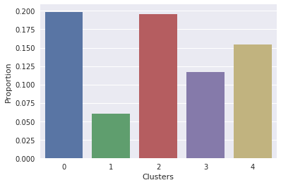

```python
# Compare the proportion of data in each cluster for the customer data to the # proportion of data in each cluster for the general population.
customer_pred = pd.DataFrame(pred_cust)
customer_pred['label'] = pred_cust

sns.set(style="darkgrid")
ax = ax = sns.barplot(x='label', y="label", data=customer_pred, estimator=lambda x: len(x) / len(customers))
ax.set(ylabel="Proportion")
ax.set(xlabel="Clusters")
```

```
[Text(0.5,0,'Clusters')]
```

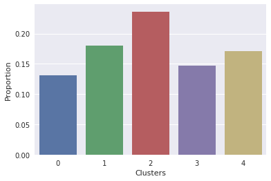

```python
population_pred = pd.DataFrame(pred)
population_pred['label'] = pred
sns.set(style="darkgrid")
ax = ax = sns.barplot(x='label', y="label", data=population_pred, estimator=lambda x: len(x) / len(azdias))
ax.set(ylabel="Proportion")
ax.set(xlabel="Clusters")
```

```python
#size of total population, including those with missing data
population_size = azdias.shape[0]
customer_size = customers.shape[0]

population_missing_cluster_size = population_size - population_pred.shape[0]
display(population_missing_cluster_size)
customer_missing_cluster_size = customer_size - customer_pred.shape[0]
display(customer_missing_cluster_size)
```

```
119520
```

```
52584
```

```python
# Add the proportion of missing rows in population data as a new cluster
new_df = pd.DataFrame(population_pred.iloc[:,0].value_counts())/azdias.shape[0]
new_df.columns = ['General Population Clusters']
new_df.loc[5] = population_missing_cluster_size/azdias.shape[0]
display(new_df)

# Add the proportion of missing rows in customer data as a new cluster
new_cdf = pd.DataFrame(customer_pred.iloc[:,0].value_counts())/customers.shape[0]
new_cdf.columns = ['Customer Clusters']
new_cdf.loc[5] = customer_missing_cluster_size/customers.shape[0]
display(new_cdf)
```

|  | General Population Clusters |
| --- | --- |
| 2 | 0.236357 |
| 1 | 0.180200 |
| 4 | 0.170549 |
| 3 | 0.147494 |
| 0 | 0.131292 |
| 5 | 0.134108 |

|  | Customer Clusters |
| --- | --- |
| 0 | 0.198746 |
| 2 | 0.195777 |
| 4 | 0.154139 |
| 3 | 0.116811 |
| 1 | 0.060156 |
| 5 | 0.274372 |

```python
# What kinds of people are part of a cluster that is overrepresented in the customer data compared to the general population?

pd.set_option('display.max_rows', 1000)
display(azdias_up.shape)
df3.shape
display(df3.median().transpose())
```

```
(119520, 79)
```

```
ALTERSKATEGORIE_GROB        2.0
ANREDE_KZ                   1.0
CJT_GESAMTTYP               6.0
FINANZ_MINIMALIST           3.0
FINANZ_SPARER               4.0
FINANZ_VORSORGER            3.0
FINANZ_ANLEGER              5.0
FINANZ_UNAUFFAELLIGER       5.0
FINANZ_HAUSBAUER            3.0
FINANZTYP                   4.0
GFK_URLAUBERTYP             5.0
GREEN_AVANTGARDE            0.0
HEALTH_TYP                  1.0
LP_LEBENSPHASE_FEIN        27.0
LP_LEBENSPHASE_GROB         8.0
LP_FAMILIE_FEIN             7.0
LP_FAMILIE_GROB             4.0
LP_STATUS_FEIN              5.0
LP_STATUS_GROB              2.0
NATIONALITAET_KZ            1.0
PRAEGENDE_JUGENDJAHRE       5.0
RETOURTYP_BK_S              3.0
SEMIO_SOZ                   2.0
SEMIO_FAM                   6.0
SEMIO_REL                   7.0
SEMIO_MAT                   5.0
SEMIO_VERT                  1.0
SEMIO_LUST                  5.0
SEMIO_ERL                   3.0
SEMIO_KULT                  3.0
SEMIO_RAT                   4.0
SEMIO_KRIT                  7.0
SEMIO_DOM                   6.0
SEMIO_KAEM                  6.0
SEMIO_PFLICHT               5.0
SEMIO_TRADV                 3.0
SHOPPER_TYP                 2.0
SOHO_KZ                     0.0
VERS_TYP                    1.0
ZABEOTYP                    3.0
```

[output cut: 23 more lines]

```
MOBI_REGIO                  4.0
ONLINE_AFFINITAET           2.0
REGIOTYP                    4.0
KBA13_ANZAHL_PKW          623.0
PLZ8_ANTG1                  2.0
PLZ8_ANTG2                  3.0
PLZ8_ANTG3                  1.0
PLZ8_ANTG4                  0.0
PLZ8_BAUMAX                 1.0
PLZ8_HHZ                    4.0
PLZ8_GBZ                    4.0
ARBEIT                      3.0
ORTSGR_KLS9                 5.0
RELAT_AB                    3.0
dtype: float64
```

```python
# What kinds of people are part of a cluster that is underrepresented in the customer data compared to the general population?
azdias_new['Clusters'] = pred
idx = azdias_new[azdias_new.Clusters==2].index
original_vals = azdias.loc[idx,:]
display(original_vals.median().transpose())
```

```
ALTERSKATEGORIE_GROB        3.0
ANREDE_KZ                   2.0
CJT_GESAMTTYP               3.0
FINANZ_MINIMALIST           3.0
FINANZ_SPARER               2.0
FINANZ_VORSORGER            5.0
FINANZ_ANLEGER              2.0
FINANZ_UNAUFFAELLIGER       1.0
FINANZ_HAUSBAUER            4.0
FINANZTYP                   5.0
GFK_URLAUBERTYP             8.0
GREEN_AVANTGARDE            0.0
HEALTH_TYP                  2.0
LP_LEBENSPHASE_FEIN         7.0
LP_LEBENSPHASE_GROB         2.0
LP_FAMILIE_FEIN             1.0
LP_FAMILIE_GROB             1.0
LP_STATUS_FEIN              1.0
LP_STATUS_GROB              1.0
NATIONALITAET_KZ            1.0
PRAEGENDE_JUGENDJAHRE       8.0
RETOURTYP_BK_S              5.0
SEMIO_SOZ                   4.0
SEMIO_FAM                   3.0
SEMIO_REL                   3.0
SEMIO_MAT                   3.0
SEMIO_VERT                  5.0
SEMIO_LUST                  6.0
SEMIO_ERL                   6.0
SEMIO_KULT                  4.0
SEMIO_RAT                   3.0
SEMIO_KRIT                  5.0
SEMIO_DOM                   5.0
SEMIO_KAEM                  5.0
SEMIO_PFLICHT               3.0
SEMIO_TRADV                 3.0
SHOPPER_TYP                 2.0
SOHO_KZ                     0.0
VERS_TYP                    2.0
ZABEOTYP                    3.0
```

[output cut: 23 more lines]

```
MOBI_REGIO                  2.0
ONLINE_AFFINITAET           1.0
REGIOTYP                    5.0
KBA13_ANZAHL_PKW          503.0
PLZ8_ANTG1                  2.0
PLZ8_ANTG2                  3.0
PLZ8_ANTG3                  2.0
PLZ8_ANTG4                  1.0
PLZ8_BAUMAX                 2.0
PLZ8_HHZ                    4.0
PLZ8_GBZ                    3.0
ARBEIT                      4.0
ORTSGR_KLS9                 7.0
RELAT_AB                    3.0
dtype: float64
```

### Discussion 3.3: Compare Customer Data to Demographics Data

(Double-click this cell and replace this text with your own text, reporting findings and conclusions from the clustering analysis.

Interestingly, the 6th cluster or cluster 5 is the one that is overrepresented in the customer data. It is more than twice the size of cluster 5 in the general population meaning that these are the people who are interested in the company's products more than other clusters.

The underrepresented cluster is Cluster 1 where the general population cluster size is nearly 3 times the customer cluster size.

## Over-represented Cluster - Popular

This cluster has 30-45 year old, German sounding males who are cross-channel enthusiasts. Financially, they have average financial interest, preparedness, home ownership; low investment, money saving; and is conspicuous. He loves nature but was not a member of the green avantgarde in his youth. He is in a minimalistic high income, home-owner family with a teenager. This customer is receptive to incentives and is a normal returner of products they are not happy with.

He is very socially-minded, dreamful, event, culturally and traditionally minded. However he is not family oriented, religious, critical-minded, sensual-minded, dominant, combative, dutiful or materialistic. He has average rationality. He is a family shopper and has neither a small office or home office. He is agreeable to insurance. He lives in a high income, two adult home with none of them having academic titles, with a high likelihood of children in the home and has lived in the home for more than 10 years.

In terms of the building where he lives: There are two households in the building in an average neighborhood, first mentioned in the database in 2007. The neighborhood has an average number of 1-2 family homes and lower share of 3-5 family homes. The other family sizes in the neighborhood are unknown. There are 17-22 homes in the microcell. This is an upper middle class area with low commercial activity in the area but purchasing power is high. There are low movement patterns and average affinity to online shopping.

The region has average unemployment both in the community and in comparison to other regions in the country. It has 20,000 to 50,000 inhabitants. On average, there are 623 cars in the region.

## Under-represented Cluster - Unpopular

There are 10 households in the building where she lives with no academic title holders in the building. The building has a mix of residential and commercial users and it was first mentioned in the database in 1992. The building is located in an average neighborhood. The area has mainly 6-10 family homes and 3-4 buildings per microcell.

> Congratulations on making it this far in the project! Before you finish, make sure to check through the entire notebook from top to bottom to make sure that your analysis follows a logical flow and all of your findings are documented in **Discussion** cells. Once you've checked over all of your work, you should export the notebook as an HTML document to submit for evaluation. You can do this from the menu, navigating to **File -> Download as -> HTML (.html)**. You will submit both that document and this notebook for your project submission.